## Goal:

The goal of this assingment is to explore NEI database and see what it says about fine particulate matter pollution in the United States over the 10-year period 1999-2008.

### Question 1:

Have total emissions from PM2.5 decreased in the United States from 1999 - 2008?

Using the NEI data set, first we sum emissions by year. This provides us with a compressed data set that allows us to plot the total emissions over the years 1999 - 2008

```r
total.emissions <- with(NEI, aggregate(Emissions, by=list(year), sum))
```

Plot total emissions over the years 1999 - 2008.

```r
png(filename="Q1.png")
plot(total.emissions, type="l", pch=18, col="black", lwd=3, ylab=" Total Emissions",
     xlab="Year", main="Annual US Total Emissions",
     ylim=c(min(total.emissions$x), max(total.emissions$x)),
     sub="Data from: National Emissions Inventory (NEI)", axes=FALSE)
points(total.emissions, type="b", pch=21, col="black", bg="black")
axis(side=1, at=c(1999,2002,2005,2008))
axis(side=2)
box()
```

### Question 2:

Have total emissions from PM2.5 decreased in Baltimore City, Maryland from 1999 to 2008? Use base plotting system

First we will subset the NEI data set to obtain the observations from Baltimore City, Maryland. After, we will use the same command as above to compress the data so we can plot total emissions for Baltimore City over the years 1999-2008.

```r
baltimore <- NEI[(NEI$fips=="24510"),]
baltimore.total.emissions <- with(baltimore,
                                  aggregate(Emissions, by=list(year), sum))
```

Plot total emission in Baltimore City, Maryland over the years 1999-2008.

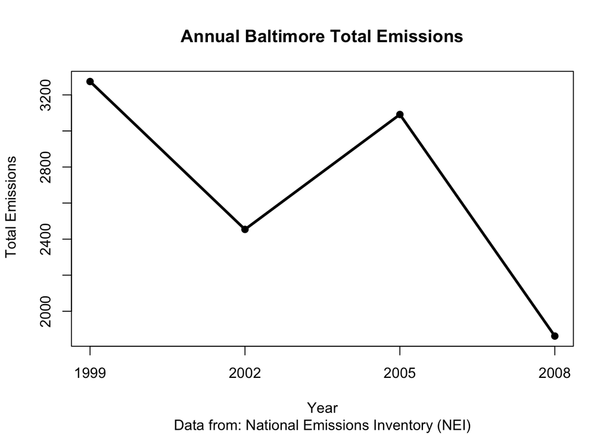

```r
plot(baltimore.total.emissions, type="l", pch=18, col="black", lwd=3,
     ylab=" Total Emissions",
     xlab="Year", main="Annual Baltimore Total Emissions",
     ylim=c(min(baltimore.total.emissions$x), max(baltimore.total.emissions$x)),
     sub="Data from: National Emissions Inventory (NEI)", axes=FALSE)
points(baltimore.total.emissions, type="b", pch=21, col="black", bg="black")
axis(side=1, at=c(1999,2002,2005,2008))
axis(side=2)
box()
```

### Question 3:

Of the four tpes of sources indicated by the type variable, which of these four sources have seen decreases in emissions from 1999-2008 for Baltimore City? Which have seen increases in emissions from 1999-2008. Use ggplot.

Here we will use the melt function from the reshape2 package and dcast to sum emissions by year and type.

```r
baltimore.2 <- melt(baltimore, id=c("year", "type"), measure.vars="Emissions")
baltimore.2 <- dcast(baltimore.2, type + year ~ variable, sum)
```

Plot Baltimore emissions by type - 1999-2008.

```r
png(filename="Q3.png")
ggplot(data=baltimore.2, aes(x=year, y=Emissions, group=type, color=type)) +
        geom_line() + geom_point(size=4, shape=21, aes(color=type, fill=type)) +
        xlab("Year") + ylab("Emissions") + ggtitle("Baltimore Emissions by Type")
```

### Question 4:

Across the US has emissions from coal combustion-related sources changed from 1999-2008?

First we will subset the SCC dataset for all short names that contain the word coal. Then we will subset SCC for the coal codes and finally we will subset the NEI dataset using our subsetted coal codes. Finally we will use the aggregate function as it was used previouslly in Q1 and Q2.

```r
subset.SCC <- grep("Coal", SCC$Short.Name, ignore.case=FALSE)
coal.codes <- SCC[subset.SCC, 1]
coal.data <- subset(NEI, NEI$SCC %in% coal.codes)
coal.total.emissions <- with(coal.data,
                                  aggregate(Emissions, by=list(year), sum))
```

Plot US emissions from coal combustion-related sources: 1999-2008.

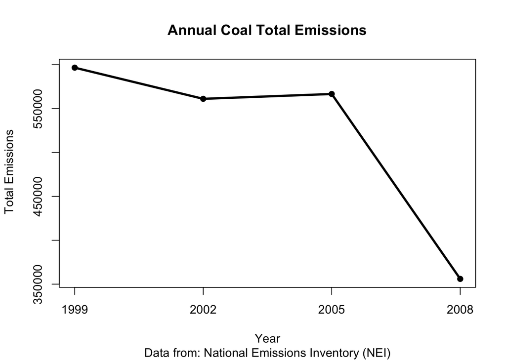

```r
plot(coal.total.emissions, type="l", pch=18, col="black", lwd=3,
     ylab=" Total Emissions",
     xlab="Year", main="Annual Coal Total Emissions",
     ylim=c(min(coal.total.emissions$x), max(coal.total.emissions$x)),
     sub="Data from: National Emissions Inventory (NEI)", axes=FALSE)
points(coal.total.emissions, type="b", pch=21, col="black", bg="black")
axis(side=1, at=c(1999,2002,2005,2008))
axis(side=2)
box()
```

### Question 5:

Have emissions from motor vehicle sources changed in 1999-2008 in Baltimore City?

Using the same subsetting strategy as in Q4, now we are subsetting on Vehicle emissions in the EI.Sector variable.

```r
subset.SCC <- grep("Vehicle", SCC$EI.Sector, ignore.case=TRUE)
vehicle.codes <- SCC[subset.SCC, 1]
motor.data.baltimore <- subset(baltimore, baltimore$SCC %in% vehicle.codes)
motor.baltimore.total <- with(motor.data.baltimore, aggregate(Emissions,
                                                              by=list(year), sum))
```

Plot motor vehicle emissions in Baltimore City: 1999-2008.

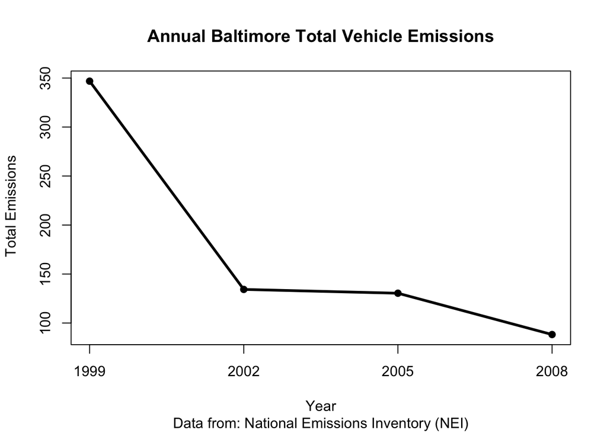

```r
plot(motor.baltimore.total, type="l", pch=18, col="black", lwd=3,
     ylab=" Total Emissions",
     xlab="Year", main="Annual Baltimore Total Vehicle Emissions",
     ylim=c(min(motor.baltimore.total$x), max(motor.baltimore.total$x)),
     sub="Data from: National Emissions Inventory (NEI)", axes=FALSE)
points(motor.baltimore.total, type="b", pch=21, col="black", bg="black")
axis(side=1, at=c(1999,2002,2005,2008))
axis(side=2)
box()
```

### Question 6:

Compare Emission from motor vehical sources Baltimore City with emissions from motor vehicle sources in LA county, California. What city has seen greater changes over time in motor vehicle emissions?

Construct a LA dataset just like the Baltimore dataset was constructed above. Combine both LA and Baltimore datasets and generate a factor variable for the two cities.

```r
losangeles <- NEI[(NEI$fips=="06037"),]
subset.SCC <- grep("Vehicle", SCC$EI.Sector, ignore.case=TRUE)
vehicle.codes <- SCC[subset.SCC, 1]
motor.data.baltimore <- subset(baltimore, baltimore$SCC %in% vehicle.codes)
motor.data.la <- subset(losangeles, losangeles$SCC %in% vehicle.codes)
motor.baltimore.total <- with(motor.data.baltimore, aggregate(Emissions,
                                                              by=list(year), sum))
motor.losangeles.total <- with(motor.data.la, aggregate(Emissions,
                                                              by=list(year), sum))

colnames(motor.losangeles.total) <- c("year","Emissions")
colnames(motor.baltimore.total) <- c("year", "Emissions")

motor.losangeles.total$city <- rep("Los Angeles", length(motor.losangeles.total$year))
motor.baltimore.total$city <- rep("Baltimore", length(motor.losangeles.total$year))

data <- rbind(motor.losangeles.total,motor.baltimore.total)

data$city <- as.factor(data$city)
```

Plot the two cities emissions against each other using ggplot. Comparing the changes between Baltimore emissions and LA emissions over the years 1999-2008.

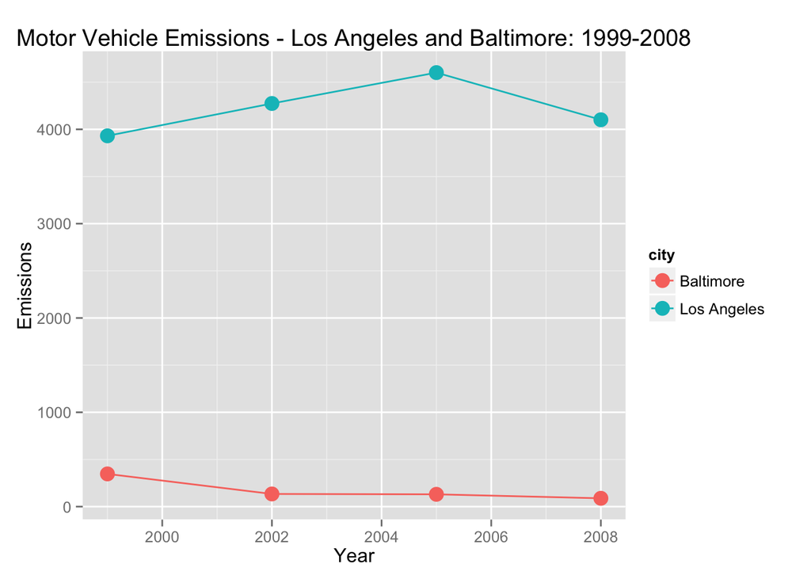

```r
ggplot(data=data, aes(x=year, y=Emissions, group=city, color=city)) +
        geom_line() + geom_point(size=4, shape=21, aes(color=city, fill=city)) +
        xlab("Year") + ylab("Emissions") +
        ggtitle("Motor Vehicle Emissions - Los Angeles and Baltimore: 1999-2008")
```